# General Sense of Dataset

# Step 0: check and install needed packages. Load the libraries and functions.

```r
packages.used=c("rvest", "tibble", "qdap",
                "sentimentr", "gplots", "dplyr",
                "tm", "syuzhet", "factoextra",
                "beeswarm", "scales", "RColorBrewer",
                "RANN", "tm", "topicmodels")
# check packages that need to be installed.
packages.needed=setdiff(packages.used,
                        intersect(installed.packages()[,1],
                                  packages.used))
# install additional packages
if(length(packages.needed)>0){
  install.packages(packages.needed, dependencies = TRUE)
}
# load packages
library("rvest")
library("tibble")
# You may need to run
# sudo ln -f -s $(/usr/libexec/java_home)/jre/lib/server/libjvm.dylib /usr/local/lib
# in order to load qdap
library("qdap")
library("sentimentr")
library("gplots")
library("dplyr")
library("tm")
library("syuzhet")
library("factoextra")
library("beeswarm")
library("scales")
library("RColorBrewer")
library("RANN")
library("tm")
library("topicmodels")
source("../lib/plotstacked.R")
source("../lib/showFuncs.R")
```

This notebook was prepared with the following environmental settings.

```r
print(R.version)
```

```
               _
platform       x86_64-apple-darwin13.4.0
arch           x86_64
os             darwin13.4.0
system         x86_64, darwin13.4.0
status
major          3
minor          3.2
year           2016
month          10
day            31
svn rev        71607
language       R
version.string R version 3.3.2 (2016-10-31)
nickname       Sincere Pumpkin Patch
```

# Step 1: Load Data

```r
show.list=read.csv("../data/shownamelist.csv", stringsAsFactors = FALSE)
```

Based on the list of showes, we scrap the main text part of the transcript’s html page. For simple html pages of this kind, [Selectorgadget](http://selectorgadget.com/) is very convenient for identifying the html node that `rvest` can use to scrap its content. For reproducibility, we also save our scrapped showes into our local folder as individual show files.

```r
# Loop over each row in show.list
show.list$fulltext=NA
for(i in seq(nrow(show.list))) {
  text <- read_html(show.list$url[i]) %>% # load the page
    #html_nodes(".displaytext") %>% # isloate the text
    html_text() # get the text
  show.list$fulltext[i]=text
  # Create the file name
  filename <- paste0("../data/script/",
                     show.list$showname[i],
                     ".txt")
  sink(file = filename) %>% # open file to write
  cat(text)  # write the file
  sink() # close the file
}
```

# Step 2: data Processing — generate list of sentences

We will use sentences as units of analysis for this project, as sentences are natural languge units for organizing thoughts and ideas. For each extracted sentence, we apply sentiment analysis using [NRC sentiment lexion](http://saifmohammad.com/WebPages/NRC-Emotion-Lexicon.htm). “The NRC Emotion Lexicon is a list of English words and their associations with eight basic emotions (anger, fear, anticipation, trust, surprise, sadness, joy, and disgust) and two sentiments (negative and positive). The annotations were manually done by crowdsourcing.”

We assign an sequential id to each sentence in a show (`sent.id`) and also calculated the number of words in each sentence as *sentence length* (`word.count`).

```r
sentence.list=NULL
for(i in 1:nrow(show.list)){
  sentences=sent_detect(show.list$fulltext[i],
                        endmarks = c("?", ".", "!", "|",";"))
  if(length(sentences)>0){
    emotions=get_nrc_sentiment(sentences)
    word.count=word_count(sentences)
    # colnames(emotions)=paste0("emo.", colnames(emotions))
    # in case the word counts are zeros?
    emotions=diag(1/(word.count+0.01))%*%as.matrix(emotions)
    sentence.list=rbind(sentence.list,
                        cbind(show.list[i,-ncol(show.list)],
                              sentences=as.character(sentences),
                              word.count,
                              emotions,
                              sent.id=1:length(sentences)
                              )
    )
  }
}
```

Some non-sentences exist in raw data due to erroneous extra end-of-sentence marks.

```r
sentence.list=
  sentence.list%>%
  filter(!is.na(word.count))
sentence.list = sentence.list[sentence.list$word.count <= 70, ]
#write.csv(sentence.list, "sentence_list.csv", row.names=FALSE)
```

# Step 3: Data analysis — length of sentences

```r
sel.comparison=c("rhonyc_801","rhonyc_802","rhonyc_803","YSHR_01011H","YSHR_01012H","YSHR_01013H","GFG_EPS301","GFG_EPS302","GFG_EPS303")
```

## Overview of sentence length distribution

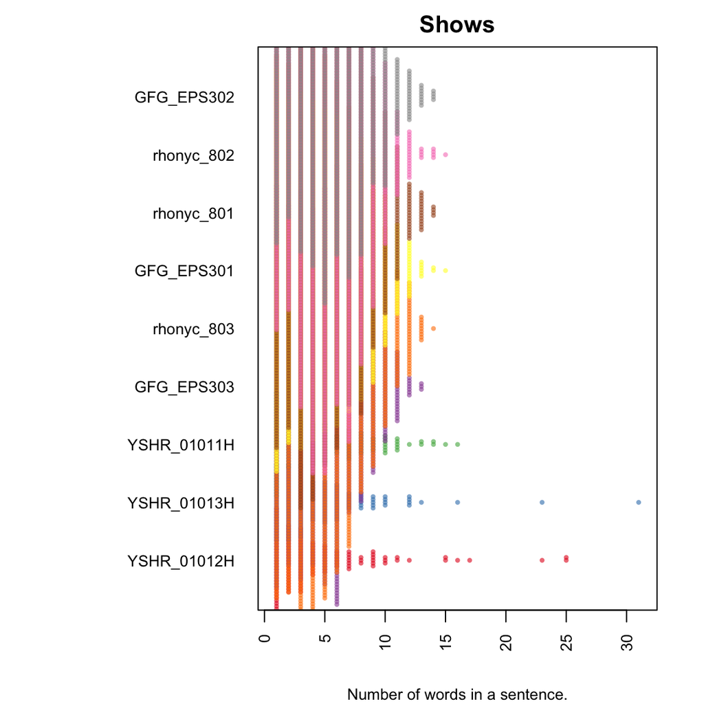

```r
par(mar=c(4, 11, 2, 2))
#sel.comparison=levels(sentence.list$File)
sentence.list.sel=filter(sentence.list,
                        File%in%sel.comparison)
sentence.list.sel$File=factor(sentence.list$File)
sentence.list.sel$FileOrdered=reorder(sentence.list.sel$File,
                                  sentence.list.sel$word.count,
                                  mean,
                                  order=T)
beeswarm(word.count~FileOrdered,
         data=sentence.list.sel,
         horizontal = TRUE,
         pch=16, col=alpha(brewer.pal(9, "Set1"), 0.6),
         cex=0.55, cex.axis=0.8, cex.lab=0.8,
         spacing=5/nlevels(sentence.list.sel$FileOrdered),
         las=2, xlab="Number of words in a sentence.", ylab="",
         main="Shows")
```

# Step 4: Data analysis — sentiment analsis

## Sentence length variation over the course of the show, with emotions.

```r
par(mfrow=c(3,3))
f.plotsent.len(In.list=sentence.list, InFile="rhonyc_801")
f.plotsent.len(In.list=sentence.list, InFile="rhonyc_802")
```

```r
f.plotsent.len(In.list=sentence.list, InFile="rhonyc_803")
f.plotsent.len(In.list=sentence.list, InFile="YSHR_01011H")
```

```r
f.plotsent.len(In.list=sentence.list, InFile="YSHR_01012H")
f.plotsent.len(In.list=sentence.list, InFile="YSHR_01013H")
```

```r
f.plotsent.len(In.list=sentence.list, InFile="GFG_EPS301")
f.plotsent.len(In.list=sentence.list, InFile="GFG_EPS302")
```

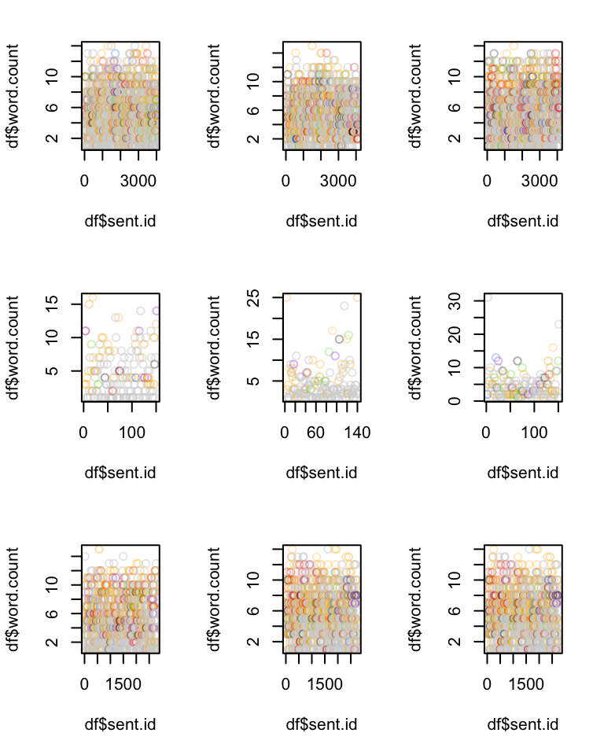

```r
f.plotsent.len(In.list=sentence.list, InFile="GFG_EPS302")
```

### What are the emotionally charged sentences?

```r
#print("rhonyc_801")
show.df=tbl_df(sentence.list)%>%
  filter(File=="rhonyc_801", word.count>=4)%>%
  select(sentences, anger:trust)
show.df=as.data.frame(show.df)
as.character(show.df$sentences[apply(show.df[,-1], 2, which.max)])
```

```
[1] "I hate that bitch."             "856 - God bless you too."       "I hate that bitch."
[4] "I hate that bitch."             "856 - God bless you too."       "I hate that bitch."
[7] "Are you not feeling very good?" "757 - She's happy at school?"
```

# Step 5: Clustering

## Clustering of emotions

### for rhonyc_801

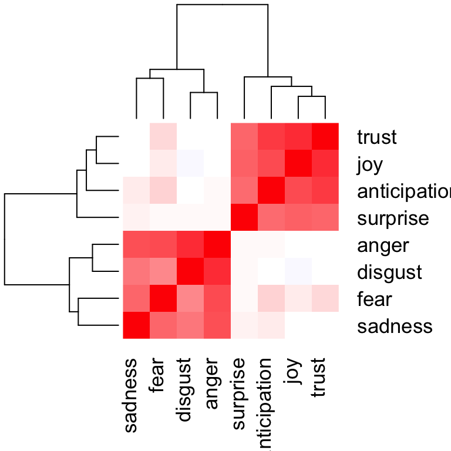

```r
heatmap.2(cor(sentence.list%>%filter(File=="rhonyc_801")%>%select(anger:trust)),
          scale = "none",
          col = bluered(100), margin=c(6, 6), key=F,
          trace = "none", density.info = "none")
par(mar=c(4, 6, 2, 1))
```

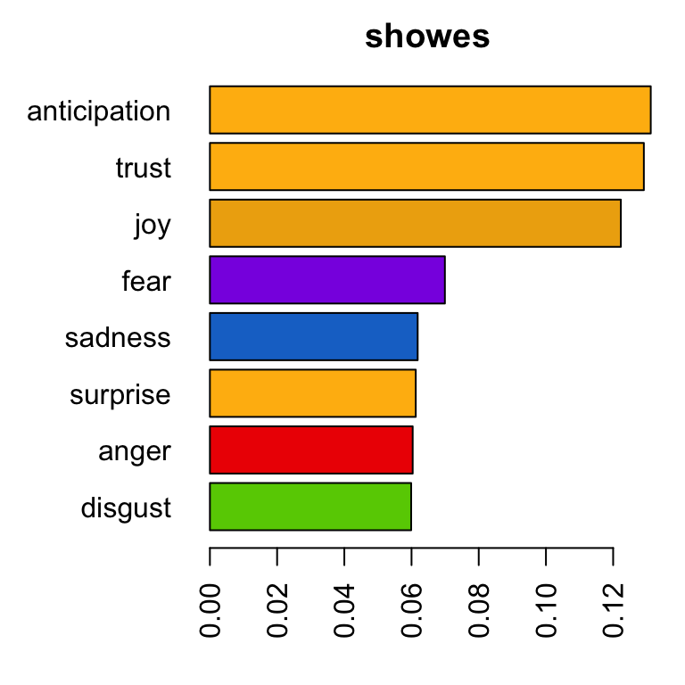

```r
emo.means=colMeans(select(sentence.list, anger:trust)>0.01)
col.use=c("red2", "darkgoldenrod1",
            "chartreuse3", "blueviolet",
            "darkgoldenrod2", "dodgerblue3",
            "darkgoldenrod1", "darkgoldenrod1")
barplot(emo.means[order(emo.means)], las=2, col=col.use[order(emo.means)], horiz=T, main="showes")
```

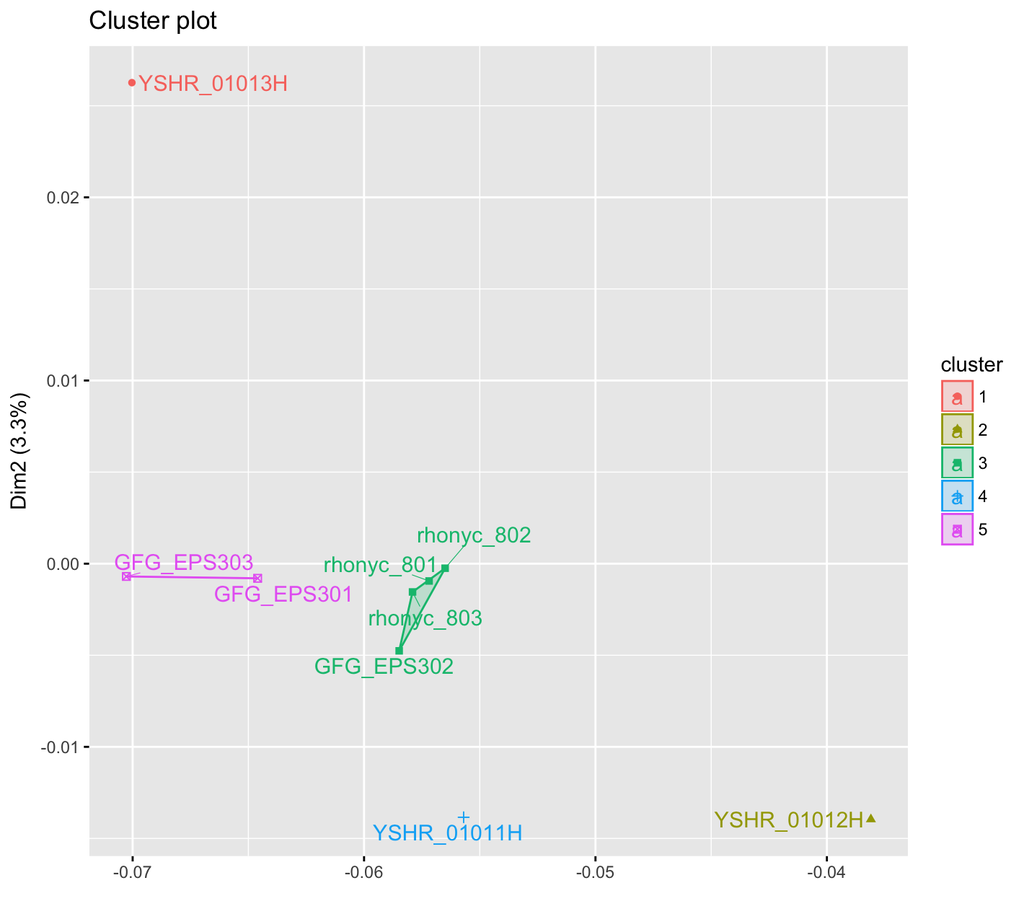

```r
presid.summary=tbl_df(sentence.list)%>%
  filter(File%in%sel.comparison)%>%
  #group_by(paste0(type, File))%>%
  group_by(File)%>%
  summarise(
    anger=mean(anger),
    anticipation=mean(anticipation),
    disgust=mean(disgust),
    fear=mean(fear),
    joy=mean(joy),
    sadness=mean(sadness),
    surprise=mean(surprise),
    trust=mean(trust)
    #negative=mean(negative),
    #positive=mean(positive)
  )
presid.summary=as.data.frame(presid.summary)
rownames(presid.summary)=as.character((presid.summary[,1]))
km.res=kmeans(presid.summary[,-1], iter.max=200,
              5)
fviz_cluster(km.res,
             stand=F, repel= TRUE,
             data = presid.summary[,-1], xlab="", xaxt="n",
             show.clust.cent=FALSE)
```

# Step 6: Data analysis — Topic modeling

For topic modeling, we prepare a corpus of sentence snipets as follows. For each show, we start with sentences and prepare a snipet with a given sentence with the flanking sentences.

```r
corpus.list=sentence.list[2:(nrow(sentence.list)-1), ]
sentence.pre=sentence.list$sentences[1:(nrow(sentence.list)-2)]
sentence.post=sentence.list$sentences[3:(nrow(sentence.list)-1)]
corpus.list$snipets=paste(sentence.pre, corpus.list$sentences, sentence.post, sep=" ")
#rm.rows=(1:nrow(corpus.list))[corpus.list$sent.id==1]
#rm.rows=c(rm.rows, rm.rows-1)
#corpus.list=corpus.list[-rm.rows, ]
```

## Text mining

```r
docs <- Corpus(VectorSource(corpus.list$snipets))
writeLines(as.character(docs[[sample(1:nrow(corpus.list), 1)]]))
```

```
169 - Just don't make it worse. 219 - What do you| 221 I mean|
```

### Text basic processing

Adapted from https://eight2late.wordpress.com/2015/09/29/a-gentle-introduction-to-topic-modeling-using-r/.

```r
#remove potentially problematic symbols
docs <-tm_map(docs,content_transformer(tolower))
writeLines(as.character(docs[[sample(1:nrow(corpus.list), 1)]]))
```

```
566 - the fact that you're even saying that is a little scary. 934 what do you mean, you get your period| 003 - because i defend myself.
```

```r
#remove punctuation
docs <- tm_map(docs, removePunctuation)
writeLines(as.character(docs[[sample(1:nrow(corpus.list), 1)]]))
```

```
059 did you see the part where i had to commit all my weekends 529  oh yeah if his team wins you are screwed
```

```r
#Strip digits
docs <- tm_map(docs, removeNumbers)
writeLines(as.character(docs[[sample(1:nrow(corpus.list), 1)]]))
```

```
  okay excuse me   out of my way please
```

```r
#remove stopwords
docs <- tm_map(docs, removeWords, stopwords("english"))
writeLines(as.character(docs[[sample(1:nrow(corpus.list), 1)]]))
```

```
  dont get overly    im scared  every time    invest  ramona  get burned
```

```r
#remove whitespace
docs <- tm_map(docs, stripWhitespace)
writeLines(as.character(docs[[sample(1:nrow(corpus.list), 1)]]))
```

```
 persuasive go sorry
```

```r
#Stem document
docs <- tm_map(docs,stemDocument)
writeLines(as.character(docs[[sample(1:nrow(corpus.list), 1)]]))
```

```
want cash want properti got cash got properti
```

### Topic modeling

Gengerate document-term matrices.

```r
dtm <- DocumentTermMatrix(docs)
#convert rownames to filenames#convert rownames to filenames
rownames(dtm) <- paste(corpus.list$type, corpus.list$File,
                       corpus.list$Term, corpus.list$sent.id, sep="_")
rowTotals <- apply(dtm , 1, sum) #Find the sum of words in each Document
dtm  <- dtm[rowTotals> 0, ]
corpus.list=corpus.list[rowTotals>0, ]
```

Run LDA

```r
#Set parameters for Gibbs sampling
burnin <- 4000
iter <- 2000
thin <- 500
seed <-list(2003,5,63,100001,765)
nstart <- 5
best <- TRUE
#Number of topics
k <- 15
#Run LDA using Gibbs sampling
ldaOut <-LDA(dtm, k, method="Gibbs", control=list(nstart=nstart,
                                                 seed = seed, best=best,
                                                 burnin = burnin, iter = iter,
                                                 thin=thin))
#write out results
#docs to topics
ldaOut.topics <- as.matrix(topics(ldaOut))
table(c(1:k, ldaOut.topics))
```

```
   1    2    3    4    5    6    7    8    9   10   11   12   13   14   15
1048  837  819  816  582  566  586  563  506  457  431  466  367  356  368
```

```r
write.csv(ldaOut.topics,file=paste("../out/LDAGibbs",k,"DocsToTopics.csv"))
#top 6 terms in each topic
ldaOut.terms <- as.matrix(terms(ldaOut,20))
write.csv(ldaOut.terms,file=paste("../out/LDAGibbs",k,"TopicsToTerms.csv"))
#probabilities associated with each topic assignment
topicProbabilities <- as.data.frame(ldaOut@gamma)
write.csv(topicProbabilities,file=paste("../out/LDAGibbs",k,"TopicProbabilities.csv"))
```

```r
terms.beta=ldaOut@beta
terms.beta=scale(terms.beta)
topics.terms=NULL
for(i in 1:k){
  topics.terms=rbind(topics.terms, ldaOut@terms[order(terms.beta[i,], decreasing = TRUE)[1:7]])
}
topics.terms
```

```
      [,1]        [,2]      [,3]     [,4]       [,5]       [,6]           [,7]
 [1,] "well"      "eat"     "touchi" "bottl"    "sir"      "disrespect"   "goos"
 [2,] "camp"      "respons" "indian" "ultim"    "ditch"    "dumb"         "longass"
 [3,] "yumbl"     "hear"    "daddi"  "dragon"   "pictur"   "roar"         "class"
 [4,] "sign"      "child"   "sour"   "princess" "tight"    "blew"         "belong"
 [5,] "dorinda"   "bed"     "sensit" "nanni"    "sake"     "scale"        "won"
 [6,] "talk"      "smile"   "deliv"  "whisk"    "royal"    "wood"         "indestruct"
 [7,] "basebal"   "charli"  "averi"  "age"      "tini"     "punish"       "hooray"
 [8,] "guy"       "though"  "oven"   "boat"     "brassier" "reach"        "doorman"
 [9,] "half"      "meatbal" "bounc"  "possibl"  "asid"     "elev"         "sass"
[10,] "told"      "artist"  "shh"    "state"    "previous" "kick"         "none"
[11,] "difficult" "notic"   "harm"   "them"     "guarante" "oscil"        "million"
[12,] "care"      "forgot"  "valid"  "stale"    "yep"      "fiberprotect" "frill"
[13,] "better"    "easi"    "import" "goo"      "legit"    "protein"      "chubbi"
[14,] "also"      "santa"   "poke"   "regret"   "process"  "washi"        "rehab"
[15,] "remind"    "eight"   "jerk"   "pack"     "dream"    "success"      "dystopian"
```

```r
ldaOut.terms
```

```
      Topic 1  Topic 2   Topic 3   Topic 4   Topic 5   Topic 6   Topic 7   Topic 8   Topic 9   Topic 10 Topic 11
 [1,] "yeah"   "just"    "one"     "look"    "like"    "want"    "gonna"   "guy"     "okay"    "new"    "think"
 [2,] "well"   "get"     "littl"   "love"    "feel"    "come"    "right"   "cant"    "need"    "back"   "realli"
 [3,] "yes"    "can"     "tell"    "thank"   "mean"    "talk"    "let"     "even"    "see"     "time"   "shes"
 [4,] "night"  "take"    "show"    "god"     "dorinda" "someth"  "now"     "parti"   "right"   "two"    "hes"
 [5,] "mean"   "time"    "home"    "hey"     "there"   "nice"    "kid"     "friend"  "ill"     "call"   "didnt"
 [6,] "last"   "help"    "togeth"  "babi"    "summer"  "idea"    "work"    "put"     "mayb"    "divorc" "caus"
 [7,] "eat"    "stuff"   "bit"     "great"   "drink"   "sit"     "stop"    "hous"    "thought" "what"   "kind"
 [8,] "pleas"  "write"   "miss"    "wow"     "get"     "meet"    "move"    "still"   "anyth"   "real"   "actual"
 [9,] "rememb" "leav"    "friend"  "hello"   "much"    "busi"    "tonight" "live"    "will"    "next"   "peopl"
[10,] "exact"  "start"   "best"    "hot"     "just"    "someon"  "coach"   "jule"    "bye"     "use"    "fine"
[11,] "guess"  "bring"   "late"    "amaz"    "havent"  "els"     "basebal" "girl"    "gonna"   "whole"  "bad"
[12,] "food"   "close"   "anoth"   "man"     "plan"    "left"    "charli"  "stay"    "like"    "ask"    "mani"
[13,] "delia"  "clear"   "made"    "mmhmm"   "ball"    "open"    "away"    "bra"     "find"    "job"    "hurt"
[14,] "total"  "okay"    "school"  "pretti"  "five"    "door"    "everyth" "luann"   "smell"   "told"   "hell"
```

[output cut: 27 more lines]

Based on the most popular terms and the most salient terms for each topic, we can not assign a hashtag to each topic. So we here temporarily keep the original names. This part require manual setup as the topics are likely to change.

```r
topics.hash=c("Topic1", "Topic2", "Topic3", "Topic4", "Topic5", "Topic6", "Topic7", "Topic8", "Topic9", "Topic10", "Topic11", "Topic12", "Topic13", "Topic14", "Topic15")
corpus.list$ldatopic=as.vector(ldaOut.topics)
corpus.list$ldahash=topics.hash[ldaOut.topics]
colnames(topicProbabilities)=topics.hash
corpus.list.df=cbind(corpus.list, topicProbabilities)
```

## Clustering of topics

```r
par(mar=c(1,1,1,1))
topic.summary=tbl_df(corpus.list.df)%>%
              filter(File%in%sel.comparison)%>%
              select(File, Topic1:Topic15)%>%
              group_by(File)%>%
              summarise_each(funs(mean))
```

```
`summarise_each()` is deprecated.
Use `summarise_all()`, `summarise_at()` or `summarise_if()` instead.
To map `funs` over all variables, use `summarise_all()`
```

```r
topic.summary=as.data.frame(topic.summary)
rownames(topic.summary)=topic.summary[,1]

topic.plot=c(1, 13, 9, 11, 8, 3, 7)
print(topics.hash[topic.plot])
```

```
[1] "Topic1"  "Topic13" "Topic9"  "Topic11" "Topic8"  "Topic3"  "Topic7"
```

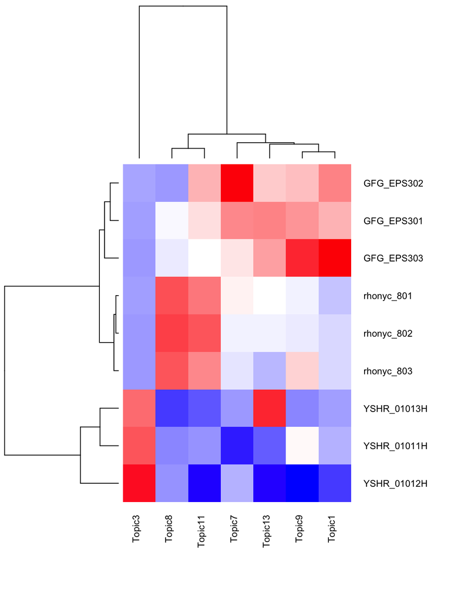

```r
heatmap.2(as.matrix(topic.summary[,topic.plot+1]),
          scale = "column", key=F,
          col = bluered(100),
          cexRow = 0.9, cexCol = 0.9, margins = c(8, 8),
          trace = "none", density.info = "none")
```

```r
par(mfrow=c(9,1), mar=c(1,1,2,0), bty="n", xaxt="n", yaxt="n")
topic.plot=c(1, 13, 9, 11, 8, 3, 7)
print(topics.hash[topic.plot])
```

```
[1] "Topic1"  "Topic13" "Topic9"  "Topic11" "Topic8"  "Topic3"  "Topic7"
```

```r
show.df=tbl_df(corpus.list.df)%>%filter(File=="rhonyc_801")%>%select(sent.id, Topic1:Topic15)
show.df=as.matrix(show.df)
show.df[,-1]=replace(show.df[,-1], show.df[,-1]<1/15, 0.001)
show.df[,-1]=f.smooth.topic(x=show.df[,1], y=show.df[,-1])
plot.stacked(show.df[,1], show.df[,topic.plot+1],
             xlab="Sentences", ylab="Topic share", main="rhonyc_801")
```

```
[1] 0.04599837 0.09199674 0.13799511 0.18399347 0.22999184 0.27599021 0.32198858
```

```r
show.df=tbl_df(corpus.list.df)%>%filter(File=="rhonyc_802")%>%select(sent.id, Topic1:Topic15)
show.df=as.matrix(show.df)
show.df[,-1]=replace(show.df[,-1], show.df[,-1]<1/15, 0.001)
show.df[,-1]=f.smooth.topic(x=show.df[,1], y=show.df[,-1])
plot.stacked(show.df[,1], show.df[,topic.plot+1],
             xlab="Sentences", ylab="Topic share", main="rhonyc_802")
```

```
[1] 0.04465255 0.08930511 0.13395766 0.17861022 0.22326277 0.26791533 0.31256788
```

```r
show.df=tbl_df(corpus.list.df)%>%filter(File=="rhonyc_803")%>%select(sent.id, Topic1:Topic15)
show.df=as.matrix(show.df)
show.df[,-1]=replace(show.df[,-1], show.df[,-1]<1/15, 0.001)
show.df[,-1]=f.smooth.topic(x=show.df[,1], y=show.df[,-1])
plot.stacked(show.df[,1], show.df[,topic.plot+1],
             xlab="Sentences", ylab="Topic share", main="rhonyc_803")
```

```
[1] 0.0431473 0.0862946 0.1294419 0.1725892 0.2157365 0.2588838 0.3020311
```

```r
show.df=tbl_df(corpus.list.df)%>%filter(File=="YSHR_01011H")%>%select(sent.id, Topic1:Topic15)
show.df=as.matrix(show.df)
show.df[,-1]=replace(show.df[,-1], show.df[,-1]<1/15, 0.001)
show.df[,-1]=f.smooth.topic(x=show.df[,1], y=show.df[,-1])
plot.stacked(show.df[,1], show.df[,topic.plot+1],
             xlab="Sentences", ylab="Topic share", main="YSHR_01011H")
```

```
[1] 0.05793986 0.11587973 0.17381959 0.23175945 0.28969932 0.34763918 0.40557904
```

```r
show.df=tbl_df(corpus.list.df)%>%filter(File=="YSHR_01012H")%>%select(sent.id, Topic1:Topic15)
show.df=as.matrix(show.df)
show.df[,-1]=replace(show.df[,-1], show.df[,-1]<1/15, 0.001)
show.df[,-1]=f.smooth.topic(x=show.df[,1], y=show.df[,-1])
plot.stacked(show.df[,1], show.df[,topic.plot+1],
             xlab="Sentences", ylab="Topic share", main="YSHR_01012H")
```

```
[1] 0.05308984 0.10617969 0.15926953 0.21235938 0.26544922 0.31853906 0.37162891
```

```r
show.df=tbl_df(corpus.list.df)%>%filter(File=="YSHR_01013H")%>%select(sent.id, Topic1:Topic15)
show.df=as.matrix(show.df)
show.df[,-1]=replace(show.df[,-1], show.df[,-1]<1/15, 0.001)
show.df[,-1]=f.smooth.topic(x=show.df[,1], y=show.df[,-1])
plot.stacked(show.df[,1], show.df[,topic.plot+1],
             xlab="Sentences", ylab="Topic share", main="YSHR_01013H")
```

```
[1] 0.05103128 0.10206257 0.15309385 0.20412513 0.25515642 0.30618770 0.35721899
```

```r
show.df=tbl_df(corpus.list.df)%>%filter(File=="GFG_EPS301")%>%select(sent.id, Topic1:Topic15)
show.df=as.matrix(show.df)
show.df[,-1]=replace(show.df[,-1], show.df[,-1]<1/15, 0.001)
show.df[,-1]=f.smooth.topic(x=show.df[,1], y=show.df[,-1])
plot.stacked(show.df[,1], show.df[,topic.plot+1],
             xlab="Sentences", ylab="Topic share", main="GFG_EPS301")
```

```
[1] 0.05255016 0.10510033 0.15765049 0.21020066 0.26275082 0.31530099 0.36785115
```

```r
show.df=tbl_df(corpus.list.df)%>%filter(File=="GFG_EPS302")%>%select(sent.id, Topic1:Topic15)
show.df=as.matrix(show.df)
show.df[,-1]=replace(show.df[,-1], show.df[,-1]<1/15, 0.001)
show.df[,-1]=f.smooth.topic(x=show.df[,1], y=show.df[,-1])
plot.stacked(show.df[,1], show.df[,topic.plot+1],
             xlab="Sentences", ylab="Topic share", main="GFG_EPS302")
```

```
[1] 0.04980815 0.09961630 0.14942445 0.19923260 0.24904075 0.29884890 0.34865706
```

```
[1] 0.04200626 0.08401252 0.12601878 0.16802504 0.21003130 0.25203757 0.29404383
```

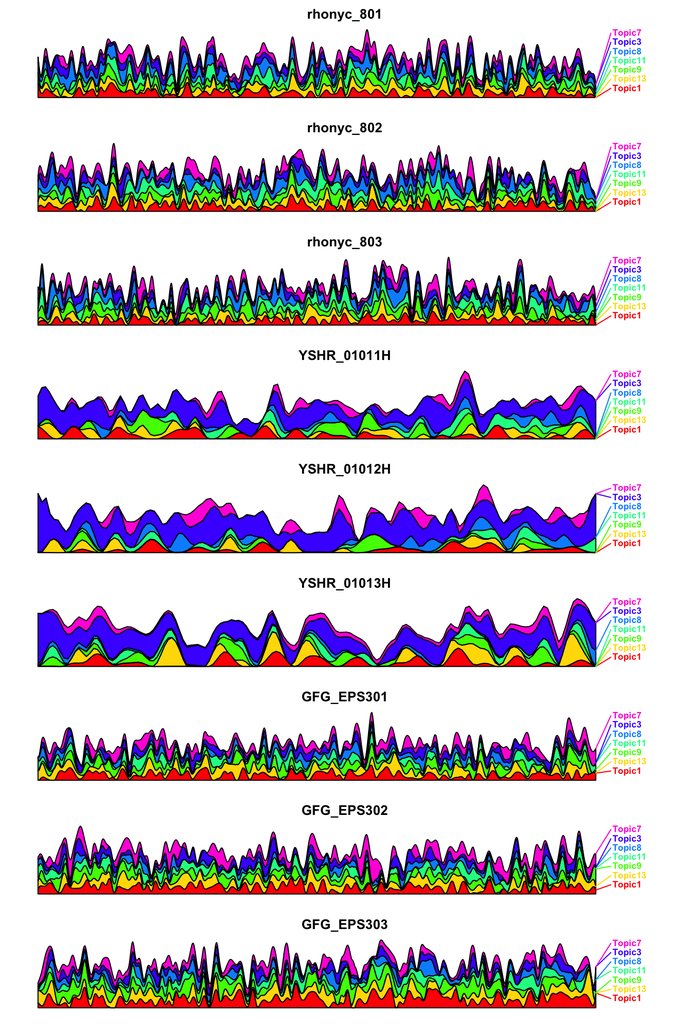

```r
show.df=tbl_df(corpus.list.df)%>%filter(File=="GFG_EPS303")%>%select(sent.id, Topic1:Topic15)
show.df=as.matrix(show.df)
show.df[,-1]=replace(show.df[,-1], show.df[,-1]<1/15, 0.001)
show.df[,-1]=f.smooth.topic(x=show.df[,1], y=show.df[,-1])
plot.stacked(show.df[,1], show.df[,topic.plot+1],
             xlab="Sentences", ylab="Topic share", main="GFG_EPS303")
```

```r
show.df=tbl_df(corpus.list.df)%>%filter(word.count<60)%>%select(sentences, Topic1:Topic15)
as.character(show.df$sentences[apply(as.data.frame(show.df[,-1]), 2, which.max)])
```

```
 [1] "324 So, what hap--anything happen last night after I left?"
 [2] "542 - But you're a good-ass writer, and writers write."
 [3] "13 01:00:31,260 --> 01:00:33,363 - BESTEST FRIENDS!"
 [4] "- Zoe, shush!"
 [5] "431 There's, like, family-nice-mom-warm Dorinda, 01:18:22."
 [6] "404 - What do you mean, talk about-- - You want to blow some lines 01:09:01."
 [7] "726 the other team just ran past his--just ran past Charlie."
 [8] "654 you can't handle me."
 [9] "371 We made a spaghetti meatball dinner 01:22:22."
[10] "- I call them mosquito bites."
[11] "204 didn't invite her 'cause of you and 'cause she's acting 01:31:49."
[12] "- Don't go."
[13] "170 01:06:11,100 --> 01:06:13,169 171 01:06:13,169 --> 01:06:14,870 - I WISH I'D BEEN HERE."
[14] "730 - No, wait, wait, wait, wait."
[15] "185 - When did they become fast and furious friends?"
```

```r
names(show.df)[-1]
```

```
 [1] "Topic1"  "Topic2"  "Topic3"  "Topic4"  "Topic5"  "Topic6"  "Topic7"  "Topic8"  "Topic9"  "Topic10" "Topic11"
[12] "Topic12" "Topic13" "Topic14" "Topic15"
```

```r
presid.summary=tbl_df(corpus.list.df)%>%
  filter(File%in%sel.comparison)%>%
  select(File, Topic1:Topic15)%>%
  group_by(File)%>%
  summarise_each(funs(mean))
```

```
`summarise_each()` is deprecated.
Use `summarise_all()`, `summarise_at()` or `summarise_if()` instead.
To map `funs` over all variables, use `summarise_all()`
```

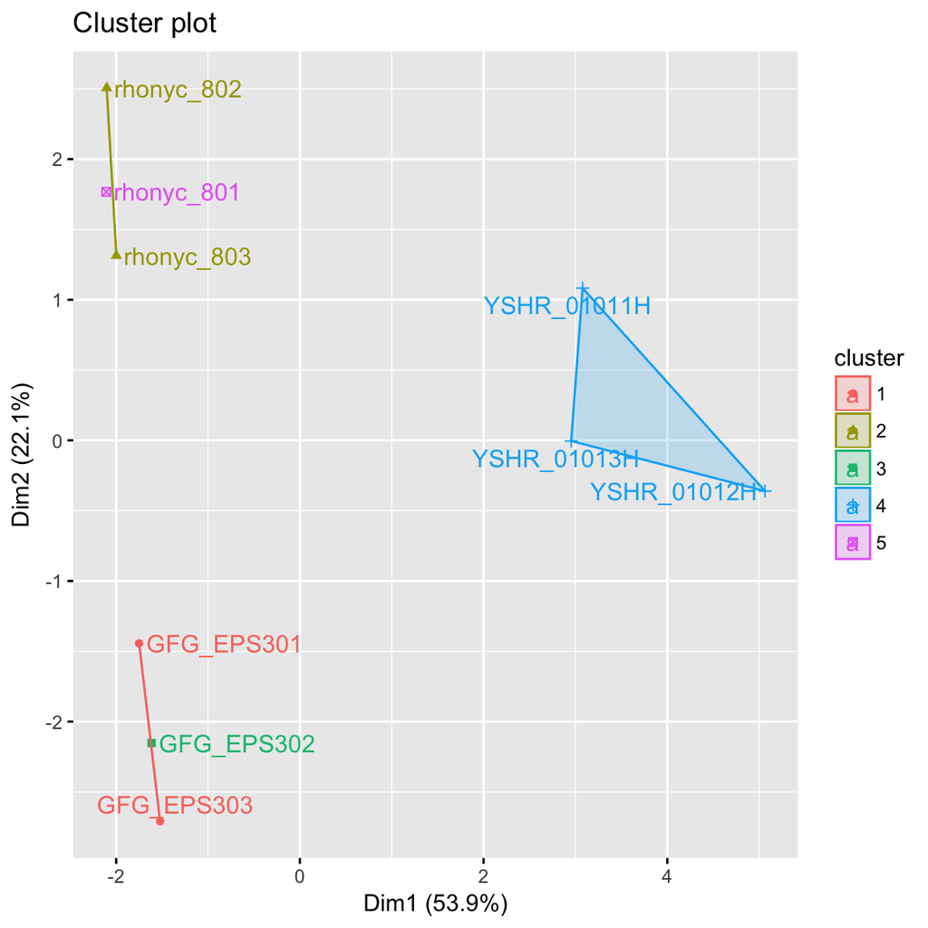

```r
presid.summary=as.data.frame(presid.summary)
rownames(presid.summary)=as.character((presid.summary[,1]))
km.res=kmeans(scale(presid.summary[,-1]), iter.max=200,
              5)
fviz_cluster(km.res,
             stand=T, repel= TRUE,
             data = presid.summary[,-1],
             show.clust.cent=FALSE)
```

# Readings for NLP with Python

- [Natural Language Processing with Python](http://www.nltk.org/book/)
- [A shorter tutorial](https://www.digitalocean.com/community/tutorials/how-to-work-with-language-data-in-python-3-using-the-natural-language-toolkit-nltk)
- [Sentiment analysis](https://pythonspot.com/en/python-sentiment-analysis/)
- [Topic modeling](https://medium.com/@aneesha/topic-modeling-with-scikit-learn-e80d33668730)